# Homework3

Brian Schetzsle

3/2/2022

# Question 1

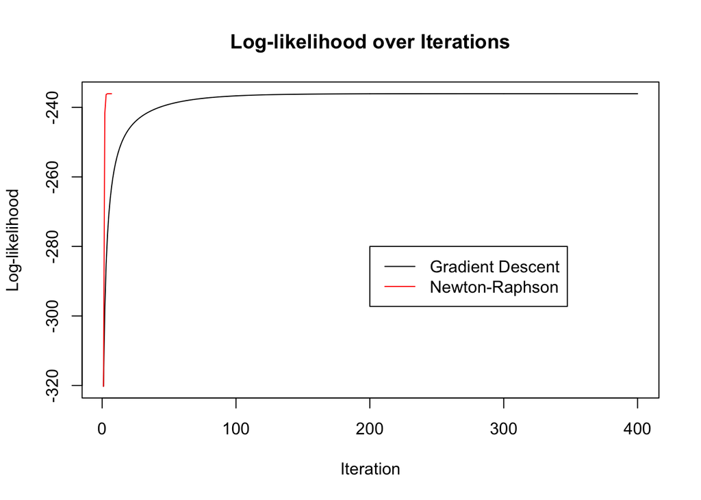

Above is a graph of the log-likelihood of visited $\beta$ coefficient vectors. The Newton-Raphson algorithm converged within 6 iterations while Gradient Descent exhausted its 400 maximum iterations (but wound up at a log-likelihood almost identical to Newton-Raphson).

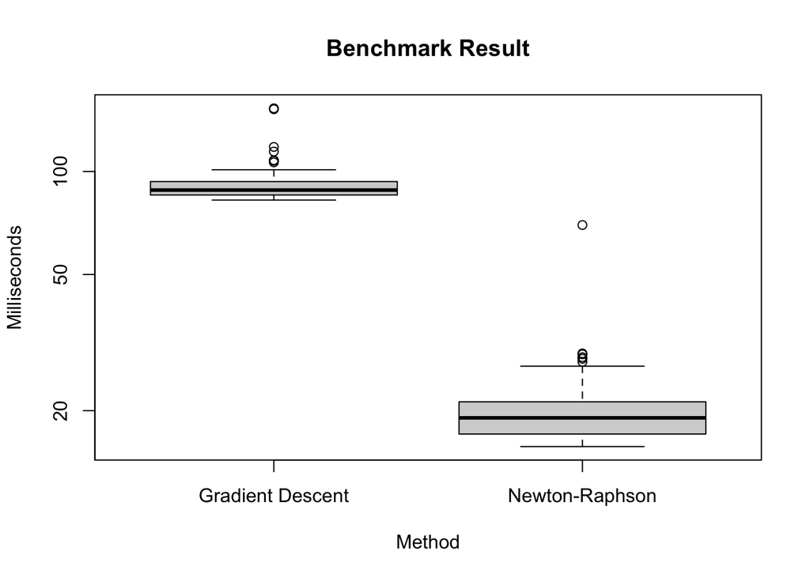

Above are the execution times of many iterations of the two optimization techniques. Newton-Raphson completes much more quickly, owing to its quick convergence.

# Question 2

Maximum Likelihood Population Proportions

| pA | pB | pO |
| --- | --- | --- |
| 0.051 | 0.359 | 0.59 |

According to the EM algorithm, the most likely distribution of alleles in the population according to the Hardy-Weinburg equilibrium model is $p_{A}=$ 0.0512497, $p_{B}=$ 0.3592176 and $p_{O}=$ 0.5895327.

# Question 3

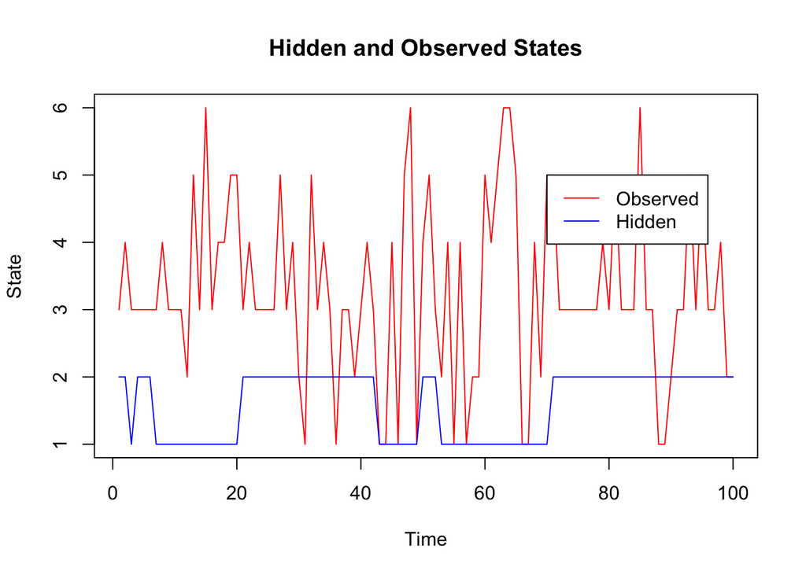

Above are the hidden and observed states of a simulated HMM. The emission probabilities are similar enough that it is not obvious which hidden state the model is in. If the model is in hidden state 2, we would expect to see more 3s but by chance may see none.

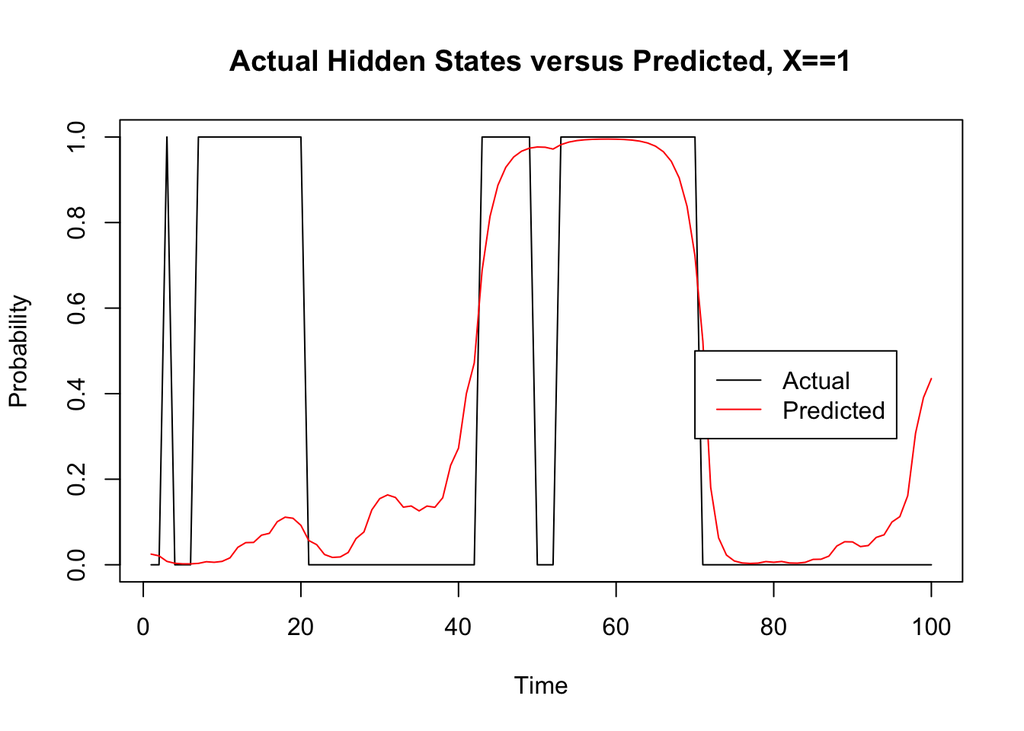

Above is the actual hidden states used to generate the observed states. The red line is the predicted state at each time point given all observed data, as well as transition, starting and emission probabilities. The forward and backward algorithms are able to recover a crude approximation of the underlying hidden state and deviations are due to random chance.

Emission Probabilities

|  | 1 | 2 | 3 | 4 | 5 | 6 |
| --- | --- | --- | --- | --- | --- | --- |
| Fair | 0.301 | 0.190 | 0.028 | 0.200 | 0.192 | 0.088 |
| Loaded | 0.025 | 0.052 | 0.627 | 0.139 | 0.128 | 0.030 |

Transition Probabilities

| 1 | 2 |
| --- | --- |
| 0.883 | 0.117 |
| 0.071 | 0.929 |

Starting Probabilities

| 0 |
| --- |
| 1 |

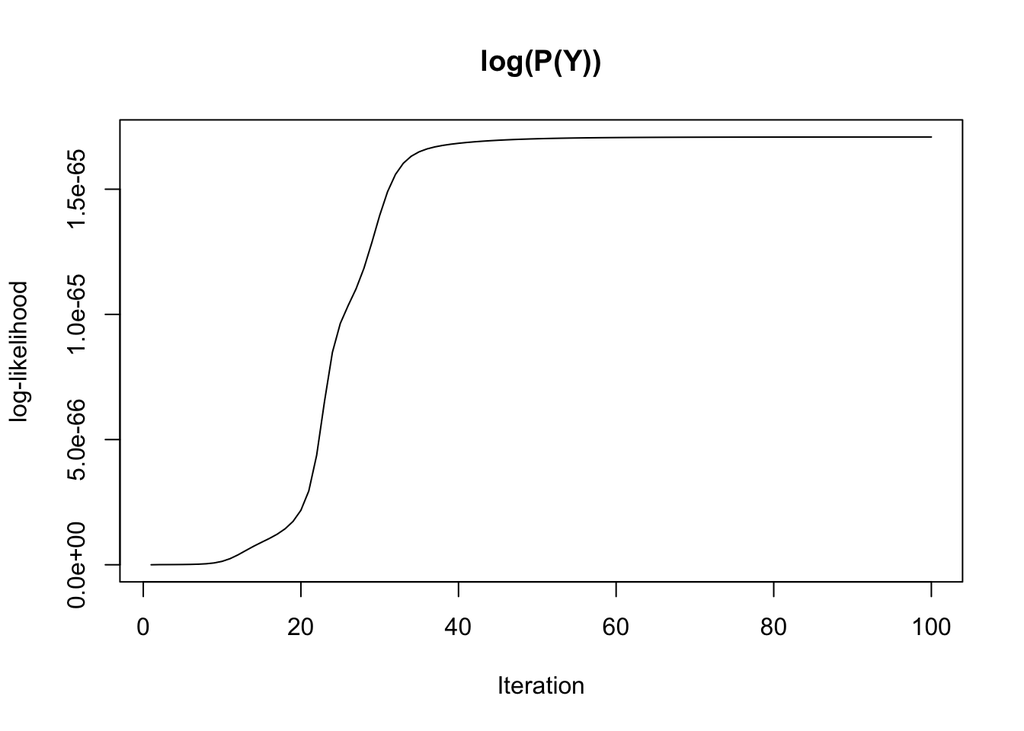

The resulting transition, emission and starting probability matrices do not look like the actual matrices used to generate the data. The log-likelihood of the data does increase over iterations of the algorithm, so Baum-Welsh does look like it is doing some optimization. However, it seems to have gotten stuck in a local maximum. I think that this problem in particular, with the emission matrix looking similar for the two hidden states, makes it difficult for this algorithm to tease out nuance.

Github repository is located here:

https://github.com/bschetzsle/STATS230